# ML_course_project

Wanjie Feng

2024-03-30

## Project Overview

Using devices such as *Jawbone Up*, *Nike FuelBand*, and *Fitbit* it is now possible to collect a large amount of data about personal activity relatively inexpensively. These type of devices are part of the quantified self movement – a group of enthusiasts who take measurements about themselves regularly to improve their health, to find patterns in their behavior, or because they are tech geeks. One thing that people regularly do is quantify *how much* of a particular activity they do, but they rarely quantify *how well* they do it. In this project, the goal will be to use data from accelerometers on the belt, forearm, arm, and dumbbell of 6 participants. They were asked to perform barbell lifts correctly and incorrectly in 5 different ways. The goal of this project is to predict the manner in which they did the exercise. This is the “classe” variable in the training set.

The training data for this project are available at:

https://d396qusza40orc.cloudfront.net/predmachlearn/pml-training.csv

The test data are available at:

https://d396qusza40orc.cloudfront.net/predmachlearn/pml-testing.csv

The outline of this project is:

- Download data
- Explore the data 1
- Clean the data
- Explore the data 2
- Build ML Model
- Summary

### 1. Download Data

```r
library(RCurl)
training_url <- "https://d396qusza40orc.cloudfront.net/predmachlearn/pml-training.csv"
x_url <- getURL(training_url)
training <- read.csv(textConnection(x_url))
testing_url <- "https://d396qusza40orc.cloudfront.net/predmachlearn/pml-testing.csv"
x_url <- getURL(testing_url)
testing <- read.csv(textConnection(x_url))
```

### 2. Explore Data 1

```r
head(training)
```

```
##   X user_name raw_timestamp_part_1 raw_timestamp_part_2   cvtd_timestamp
## 1 1  carlitos           1323084231               788290 05/12/2011 11:23
## 2 2  carlitos           1323084231               808298 05/12/2011 11:23
## 3 3  carlitos           1323084231               820366 05/12/2011 11:23
## 4 4  carlitos           1323084232               120339 05/12/2011 11:23
## 5 5  carlitos           1323084232               196328 05/12/2011 11:23
## 6 6  carlitos           1323084232               304277 05/12/2011 11:23
##   new_window num_window roll_belt pitch_belt yaw_belt total_accel_belt
## 1         no         11      1.41       8.07    -94.4                3
## 2         no         11      1.41       8.07    -94.4                3
## 3         no         11      1.42       8.07    -94.4                3
## 4         no         12      1.48       8.05    -94.4                3
## 5         no         12      1.48       8.07    -94.4                3
## 6         no         12      1.45       8.06    -94.4                3
##   kurtosis_roll_belt kurtosis_picth_belt kurtosis_yaw_belt skewness_roll_belt
```

[output cut: 251 more lines]

There are 160 columns in this training data set. We can see that there are empty and NA values. We need to clean them.

```r
dim(training)
```

```
## [1] 19622   160
```

There are 19622 samples and 160 features in the training data set.

```r
table(training$classe)
```

```
##
##    A    B    C    D    E
## 5580 3797 3422 3216 3607
```

We can see the data samples for each classe.

```r
head(testing)
```

```
##   X user_name raw_timestamp_part_1 raw_timestamp_part_2   cvtd_timestamp
## 1 1     pedro           1323095002               868349 05/12/2011 14:23
## 2 2    jeremy           1322673067               778725 30/11/2011 17:11
## 3 3    jeremy           1322673075               342967 30/11/2011 17:11
## 4 4    adelmo           1322832789               560311 02/12/2011 13:33
## 5 5    eurico           1322489635               814776 28/11/2011 14:13
## 6 6    jeremy           1322673149               510661 30/11/2011 17:12
##   new_window num_window roll_belt pitch_belt yaw_belt total_accel_belt
## 1         no         74    123.00      27.00    -4.75               20
## 2         no        431      1.02       4.87   -88.90                4
## 3         no        439      0.87       1.82   -88.50                5
## 4         no        194    125.00     -41.60   162.00               17
## 5         no        235      1.35       3.33   -88.60                3
## 6         no        504     -5.92       1.59   -87.70                4
##   kurtosis_roll_belt kurtosis_picth_belt kurtosis_yaw_belt skewness_roll_belt
```

[output cut: 251 more lines]

There are empty and NA values in the testing data set. We need to first clean them.

```r
dim(testing)
```

```
## [1]  20 160
```

There are 20 samples and 160 features in testing data set.

### 3. Clean the Data

#### 3.1 Replace empty cells with NA

```r
training[training==''] <-NA
testing[testing=='']<-NA
```

#### 3.2 Remove columns with all NA

```r
training <- training[,colSums(is.na(training))<nrow(training)]
testing <- testing[,colSums(is.na(testing))<nrow(testing)]
```

```r
head(training)
```

```
##   X user_name raw_timestamp_part_1 raw_timestamp_part_2   cvtd_timestamp
## 1 1  carlitos           1323084231               788290 05/12/2011 11:23
## 2 2  carlitos           1323084231               808298 05/12/2011 11:23
## 3 3  carlitos           1323084231               820366 05/12/2011 11:23
## 4 4  carlitos           1323084232               120339 05/12/2011 11:23
## 5 5  carlitos           1323084232               196328 05/12/2011 11:23
## 6 6  carlitos           1323084232               304277 05/12/2011 11:23
##   new_window num_window roll_belt pitch_belt yaw_belt total_accel_belt
## 1         no         11      1.41       8.07    -94.4                3
## 2         no         11      1.41       8.07    -94.4                3
## 3         no         11      1.42       8.07    -94.4                3
## 4         no         12      1.48       8.05    -94.4                3
## 5         no         12      1.48       8.07    -94.4                3
## 6         no         12      1.45       8.06    -94.4                3
##   kurtosis_roll_belt kurtosis_picth_belt kurtosis_yaw_belt skewness_roll_belt
```

[output cut: 251 more lines]

There are no columns in training data which are all NA.

```r
head(testing)
```

```
##   X user_name raw_timestamp_part_1 raw_timestamp_part_2   cvtd_timestamp
## 1 1     pedro           1323095002               868349 05/12/2011 14:23
## 2 2    jeremy           1322673067               778725 30/11/2011 17:11
## 3 3    jeremy           1322673075               342967 30/11/2011 17:11
## 4 4    adelmo           1322832789               560311 02/12/2011 13:33
## 5 5    eurico           1322489635               814776 28/11/2011 14:13
## 6 6    jeremy           1322673149               510661 30/11/2011 17:12
##   new_window num_window roll_belt pitch_belt yaw_belt total_accel_belt
## 1         no         74    123.00      27.00    -4.75               20
## 2         no        431      1.02       4.87   -88.90                4
## 3         no        439      0.87       1.82   -88.50                5
## 4         no        194    125.00     -41.60   162.00               17
## 5         no        235      1.35       3.33   -88.60                3
## 6         no        504     -5.92       1.59   -87.70                4
##   gyros_belt_x gyros_belt_y gyros_belt_z accel_belt_x accel_belt_y accel_belt_z
```

[output cut: 69 more lines]

There are 100 columns removed in testing data. Since testing data are used to evaluate the machine learning models, we need to keep their features identical. Therefore, we can remove the 100 columns to keep training and testing data sets have same data features.

```r
col_names <- names(testing)
training <- subset(training, select = c(col_names[1:59],"classe"))
```

### 3.3 Remove Features

There are descriptive columns, which can be removed for machine learning.

```r
training <-subset(training, select=-c(X, user_name, raw_timestamp_part_1,
            raw_timestamp_part_2, cvtd_timestamp, new_window, num_window))
testing <- subset(testing, select=-c(X, user_name, raw_timestamp_part_1,
            raw_timestamp_part_2, cvtd_timestamp, new_window, num_window))
```

Next, we view the data again.

```r
head(training)
```

```
##   roll_belt pitch_belt yaw_belt total_accel_belt gyros_belt_x gyros_belt_y
## 1      1.41       8.07    -94.4                3         0.00         0.00
## 2      1.41       8.07    -94.4                3         0.02         0.00
## 3      1.42       8.07    -94.4                3         0.00         0.00
## 4      1.48       8.05    -94.4                3         0.02         0.00
## 5      1.48       8.07    -94.4                3         0.02         0.02
## 6      1.45       8.06    -94.4                3         0.02         0.00
##   gyros_belt_z accel_belt_x accel_belt_y accel_belt_z magnet_belt_x
## 1        -0.02          -21            4           22            -3
## 2        -0.02          -22            4           22            -7
## 3        -0.02          -20            5           23            -2
## 4        -0.03          -22            3           21            -6
## 5        -0.02          -21            2           24            -6
## 6        -0.02          -21            4           21             0
##   magnet_belt_y magnet_belt_z roll_arm pitch_arm yaw_arm total_accel_arm
```

[output cut: 62 more lines]

```r
head(testing)
```

```
##   roll_belt pitch_belt yaw_belt total_accel_belt gyros_belt_x gyros_belt_y
## 1    123.00      27.00    -4.75               20        -0.50        -0.02
## 2      1.02       4.87   -88.90                4        -0.06        -0.02
## 3      0.87       1.82   -88.50                5         0.05         0.02
## 4    125.00     -41.60   162.00               17         0.11         0.11
## 5      1.35       3.33   -88.60                3         0.03         0.02
## 6     -5.92       1.59   -87.70                4         0.10         0.05
##   gyros_belt_z accel_belt_x accel_belt_y accel_belt_z magnet_belt_x
## 1        -0.46          -38           69         -179           -13
## 2        -0.07          -13           11           39            43
## 3         0.03            1           -1           49            29
## 4        -0.16           46           45         -156           169
## 5         0.00           -8            4           27            33
## 6        -0.13          -11          -16           38            31
##   magnet_belt_y magnet_belt_z roll_arm pitch_arm yaw_arm total_accel_arm
```

[output cut: 62 more lines]

After cleaning the data, there are 53 columns left in training and testing data sets. Next, we visualize those data.

### 3. Explore the Data - 2

```r
summary(training)
```

```
##    roll_belt        pitch_belt          yaw_belt       total_accel_belt
##  Min.   :-28.90   Min.   :-55.8000   Min.   :-180.00   Min.   : 0.00
##  1st Qu.:  1.10   1st Qu.:  1.7600   1st Qu.: -88.30   1st Qu.: 3.00
##  Median :113.00   Median :  5.2800   Median : -13.00   Median :17.00
##  Mean   : 64.41   Mean   :  0.3053   Mean   : -11.21   Mean   :11.31
##  3rd Qu.:123.00   3rd Qu.: 14.9000   3rd Qu.:  12.90   3rd Qu.:18.00
##  Max.   :162.00   Max.   : 60.3000   Max.   : 179.00   Max.   :29.00
##   gyros_belt_x        gyros_belt_y       gyros_belt_z      accel_belt_x
##  Min.   :-1.040000   Min.   :-0.64000   Min.   :-1.4600   Min.   :-120.000
##  1st Qu.:-0.030000   1st Qu.: 0.00000   1st Qu.:-0.2000   1st Qu.: -21.000
##  Median : 0.030000   Median : 0.02000   Median :-0.1000   Median : -15.000
##  Mean   :-0.005592   Mean   : 0.03959   Mean   :-0.1305   Mean   :  -5.595
##  3rd Qu.: 0.110000   3rd Qu.: 0.11000   3rd Qu.:-0.0200   3rd Qu.:  -5.000
##  Max.   : 2.220000   Max.   : 0.64000   Max.   : 1.6200   Max.   :  85.000
##   accel_belt_y     accel_belt_z     magnet_belt_x   magnet_belt_y
##  Min.   :-69.00   Min.   :-275.00   Min.   :-52.0   Min.   :354.0
##  1st Qu.:  3.00   1st Qu.:-162.00   1st Qu.:  9.0   1st Qu.:581.0
##  Median : 35.00   Median :-152.00   Median : 35.0   Median :601.0
##  Mean   : 30.15   Mean   : -72.59   Mean   : 55.6   Mean   :593.7
##  3rd Qu.: 61.00   3rd Qu.:  27.00   3rd Qu.: 59.0   3rd Qu.:610.0
##  Max.   :164.00   Max.   : 105.00   Max.   :485.0   Max.   :673.0
##  magnet_belt_z       roll_arm         pitch_arm          yaw_arm
##  Min.   :-623.0   Min.   :-180.00   Min.   :-88.800   Min.   :-180.0000
##  1st Qu.:-375.0   1st Qu.: -31.77   1st Qu.:-25.900   1st Qu.: -43.1000
##  Median :-320.0   Median :   0.00   Median :  0.000   Median :   0.0000
##  Mean   :-345.5   Mean   :  17.83   Mean   : -4.612   Mean   :  -0.6188
##  3rd Qu.:-306.0   3rd Qu.:  77.30   3rd Qu.: 11.200   3rd Qu.:  45.8750
##  Max.   : 293.0   Max.   : 180.00   Max.   : 88.500   Max.   : 180.0000
##  total_accel_arm  gyros_arm_x        gyros_arm_y       gyros_arm_z
##  Min.   : 1.00   Min.   :-6.37000   Min.   :-3.4400   Min.   :-2.3300
##  1st Qu.:17.00   1st Qu.:-1.33000   1st Qu.:-0.8000   1st Qu.:-0.0700
##  Median :27.00   Median : 0.08000   Median :-0.2400   Median : 0.2300
##  Mean   :25.51   Mean   : 0.04277   Mean   :-0.2571   Mean   : 0.2695
##  3rd Qu.:33.00   3rd Qu.: 1.57000   3rd Qu.: 0.1400   3rd Qu.: 0.7200
##  Max.   :66.00   Max.   : 4.87000   Max.   : 2.8400   Max.   : 3.0200
##   accel_arm_x       accel_arm_y      accel_arm_z       magnet_arm_x
##  Min.   :-404.00   Min.   :-318.0   Min.   :-636.00   Min.   :-584.0
##  1st Qu.:-242.00   1st Qu.: -54.0   1st Qu.:-143.00   1st Qu.:-300.0
##  Median : -44.00   Median :  14.0   Median : -47.00   Median : 289.0
##  Mean   : -60.24   Mean   :  32.6   Mean   : -71.25   Mean   : 191.7
```

[output cut: 43 more lines]

```
##  Max.   :311.00000   Max.   :231.0000   Max.   : 477.00   Max.   : 923.0
##  accel_forearm_z   magnet_forearm_x  magnet_forearm_y magnet_forearm_z
##  Min.   :-446.00   Min.   :-1280.0   Min.   :-896.0   Min.   :-973.0
##  1st Qu.:-182.00   1st Qu.: -616.0   1st Qu.:   2.0   1st Qu.: 191.0
##  Median : -39.00   Median : -378.0   Median : 591.0   Median : 511.0
##  Mean   : -55.29   Mean   : -312.6   Mean   : 380.1   Mean   : 393.6
##  3rd Qu.:  26.00   3rd Qu.:  -73.0   3rd Qu.: 737.0   3rd Qu.: 653.0
##  Max.   : 291.00   Max.   :  672.0   Max.   :1480.0   Max.   :1090.0
##     classe
##  Length:19622
##  Class :character
##  Mode  :character
##
##
##
```

```r
summary(testing)
```

```
##    roll_belt          pitch_belt         yaw_belt      total_accel_belt
##  Min.   : -5.9200   Min.   :-41.600   Min.   :-93.70   Min.   : 2.00
##  1st Qu.:  0.9075   1st Qu.:  3.013   1st Qu.:-88.62   1st Qu.: 3.00
##  Median :  1.1100   Median :  4.655   Median :-87.85   Median : 4.00
##  Mean   : 31.3055   Mean   :  5.824   Mean   :-59.30   Mean   : 7.55
##  3rd Qu.: 32.5050   3rd Qu.:  6.135   3rd Qu.:-63.50   3rd Qu.: 8.00
##  Max.   :129.0000   Max.   : 27.800   Max.   :162.00   Max.   :21.00
##   gyros_belt_x     gyros_belt_y     gyros_belt_z      accel_belt_x
##  Min.   :-0.500   Min.   :-0.050   Min.   :-0.4800   Min.   :-48.00
##  1st Qu.:-0.070   1st Qu.:-0.005   1st Qu.:-0.1375   1st Qu.:-19.00
##  Median : 0.020   Median : 0.000   Median :-0.0250   Median :-13.00
##  Mean   :-0.045   Mean   : 0.010   Mean   :-0.1005   Mean   :-13.50
##  3rd Qu.: 0.070   3rd Qu.: 0.020   3rd Qu.: 0.0000   3rd Qu.: -8.75
##  Max.   : 0.240   Max.   : 0.110   Max.   : 0.0500   Max.   : 46.00
##   accel_belt_y     accel_belt_z     magnet_belt_x    magnet_belt_y
##  Min.   :-16.00   Min.   :-187.00   Min.   :-13.00   Min.   :566.0
##  1st Qu.:  2.00   1st Qu.: -24.00   1st Qu.:  5.50   1st Qu.:578.5
##  Median :  4.50   Median :  27.00   Median : 33.50   Median :600.5
##  Mean   : 18.35   Mean   : -17.60   Mean   : 35.15   Mean   :601.5
##  3rd Qu.: 25.50   3rd Qu.:  38.25   3rd Qu.: 46.25   3rd Qu.:631.2
##  Max.   : 72.00   Max.   :  49.00   Max.   :169.00   Max.   :638.0
##  magnet_belt_z       roll_arm         pitch_arm          yaw_arm
##  Min.   :-426.0   Min.   :-137.00   Min.   :-63.800   Min.   :-167.00
##  1st Qu.:-398.5   1st Qu.:   0.00   1st Qu.: -9.188   1st Qu.: -60.15
##  Median :-313.5   Median :   0.00   Median :  0.000   Median :   0.00
##  Mean   :-346.9   Mean   :  16.42   Mean   : -3.950   Mean   :  -2.80
##  3rd Qu.:-305.0   3rd Qu.:  71.53   3rd Qu.:  3.465   3rd Qu.:  25.50
##  Max.   :-291.0   Max.   : 152.00   Max.   : 55.000   Max.   : 178.00
##  total_accel_arm  gyros_arm_x      gyros_arm_y       gyros_arm_z
##  Min.   : 3.00   Min.   :-3.710   Min.   :-2.0900   Min.   :-0.6900
##  1st Qu.:20.25   1st Qu.:-0.645   1st Qu.:-0.6350   1st Qu.:-0.1800
##  Median :29.50   Median : 0.020   Median :-0.0400   Median :-0.0250
##  Mean   :26.40   Mean   : 0.077   Mean   :-0.1595   Mean   : 0.1205
##  3rd Qu.:33.25   3rd Qu.: 1.248   3rd Qu.: 0.2175   3rd Qu.: 0.5650
##  Max.   :44.00   Max.   : 3.660   Max.   : 1.8500   Max.   : 1.1300
##   accel_arm_x      accel_arm_y      accel_arm_z       magnet_arm_x
##  Min.   :-341.0   Min.   :-65.00   Min.   :-404.00   Min.   :-428.00
##  1st Qu.:-277.0   1st Qu.: 52.25   1st Qu.:-128.50   1st Qu.:-373.75
##  Median :-194.5   Median :112.00   Median : -83.50   Median :-265.00
##  Mean   :-134.6   Mean   :103.10   Mean   : -87.85   Mean   : -38.95
```

[output cut: 43 more lines]

```
##  Max.   : 4.2600   Max.   : 1.8000   Max.   : 232.0   Max.   : 406.0
##  accel_forearm_z  magnet_forearm_x magnet_forearm_y magnet_forearm_z
##  Min.   :-282.0   Min.   :-714.0   Min.   :-787.0   Min.   :-32.0
##  1st Qu.:-199.0   1st Qu.:-427.2   1st Qu.:-328.8   1st Qu.:275.2
##  Median :-148.5   Median :-189.5   Median : 487.0   Median :491.5
##  Mean   : -93.7   Mean   :-159.2   Mean   : 191.8   Mean   :460.2
##  3rd Qu.: -31.0   3rd Qu.:  41.5   3rd Qu.: 720.8   3rd Qu.:661.5
##  Max.   : 179.0   Max.   : 532.0   Max.   : 800.0   Max.   :884.0
##    problem_id
##  Min.   : 1.00
##  1st Qu.: 5.75
##  Median :10.50
##  Mean   :10.50
##  3rd Qu.:15.25
##  Max.   :20.00
```

Since the website is not accessible anymore, it’s hard to know what all those features are in training and testing data sets. Here first visualizes the variables. Since there are 53 columns or features, it’s hard to make a single plot including all variables. Because these data were collected from accelerometers on different targets, we can visualize the data on each target.

```r
names <- names(training)
names
```

```
##  [1] "roll_belt"            "pitch_belt"           "yaw_belt"
##  [4] "total_accel_belt"     "gyros_belt_x"         "gyros_belt_y"
##  [7] "gyros_belt_z"         "accel_belt_x"         "accel_belt_y"
## [10] "accel_belt_z"         "magnet_belt_x"        "magnet_belt_y"
## [13] "magnet_belt_z"        "roll_arm"             "pitch_arm"
## [16] "yaw_arm"              "total_accel_arm"      "gyros_arm_x"
## [19] "gyros_arm_y"          "gyros_arm_z"          "accel_arm_x"
## [22] "accel_arm_y"          "accel_arm_z"          "magnet_arm_x"
## [25] "magnet_arm_y"         "magnet_arm_z"         "roll_dumbbell"
## [28] "pitch_dumbbell"       "yaw_dumbbell"         "total_accel_dumbbell"
## [31] "gyros_dumbbell_x"     "gyros_dumbbell_y"     "gyros_dumbbell_z"
## [34] "accel_dumbbell_x"     "accel_dumbbell_y"     "accel_dumbbell_z"
## [37] "magnet_dumbbell_x"    "magnet_dumbbell_y"    "magnet_dumbbell_z"
## [40] "roll_forearm"         "pitch_forearm"        "yaw_forearm"
## [43] "total_accel_forearm"  "gyros_forearm_x"      "gyros_forearm_y"
## [46] "gyros_forearm_z"      "accel_forearm_x"      "accel_forearm_y"
## [49] "accel_forearm_z"      "magnet_forearm_x"     "magnet_forearm_y"
## [52] "magnet_forearm_z"     "classe"
```

From the column names, we can see that there are data collected on the belt, arm, dumbbell, and forearm. We can use these keys to make all the plots.

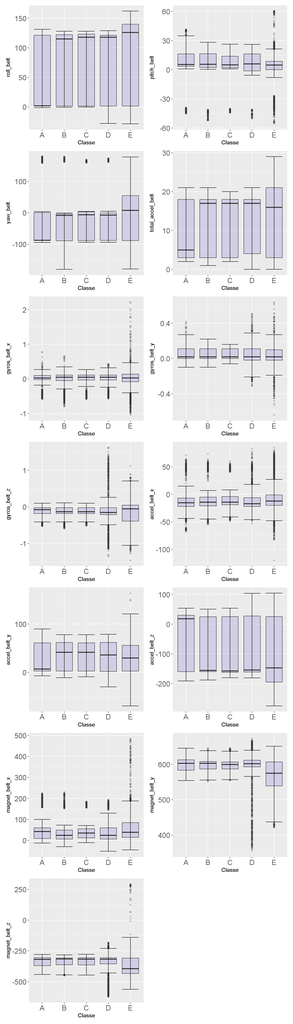

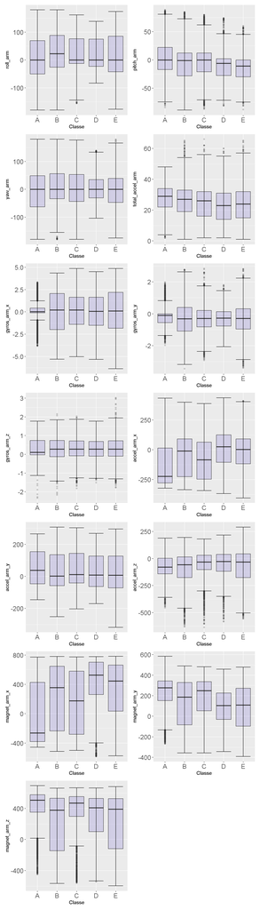

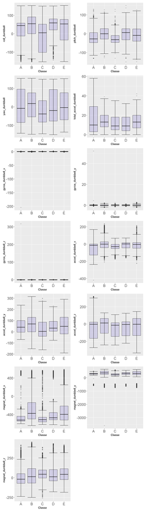

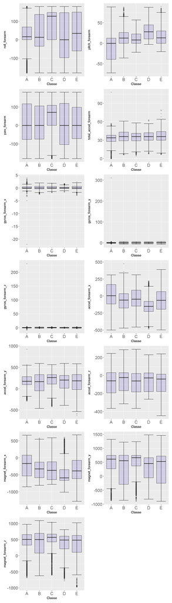

From those plots, we can get some insights about those data.

### 5. Build ML Models

Since this is a classification problem, here uses random tree and random forest to train those data. Note that the testing data set don’t have variable *classe*. It’s not useful to test the model using it. Here splits the training data first.

#### 5.1 Split Training Data

```r
library(caret)
inTrain <- createDataPartition(y=training$classe,
                               p=0.75, list=FALSE)
train_data <- training[inTrain,]
test_data <- training[-inTrain,]
print(dim(train_data))
```

```
## [1] 14718    53
```

```r
print(dim(test_data))
```

```
## [1] 4904   53
```

#### 5.2 Classification Trees

```r
set.seed(42432)
mod_tree <- train(as.factor(classe)~., method="rpart",data=train_data)
print(mod_tree$finalModel)
```

```
## n= 14718
##
## node), split, n, loss, yval, (yprob)
##       * denotes terminal node
##
##  1) root 14718 10533 A (0.28 0.19 0.17 0.16 0.18)
##    2) roll_belt< 130.5 13503  9326 A (0.31 0.21 0.19 0.18 0.11)
##      4) pitch_forearm< -33.95 1188     5 A (1 0.0042 0 0 0) *
##      5) pitch_forearm>=-33.95 12315  9321 A (0.24 0.23 0.21 0.2 0.12)
##       10) magnet_dumbbell_y< 438.5 10403  7475 A (0.28 0.18 0.24 0.19 0.11)
##         20) roll_forearm< 124.5 6475  3838 A (0.41 0.18 0.19 0.17 0.059) *
##         21) roll_forearm>=124.5 3928  2640 C (0.074 0.18 0.33 0.23 0.19) *
##       11) magnet_dumbbell_y>=438.5 1912   950 B (0.035 0.5 0.04 0.22 0.2) *
##    3) roll_belt>=130.5 1215     8 E (0.0066 0 0 0 0.99) *
```

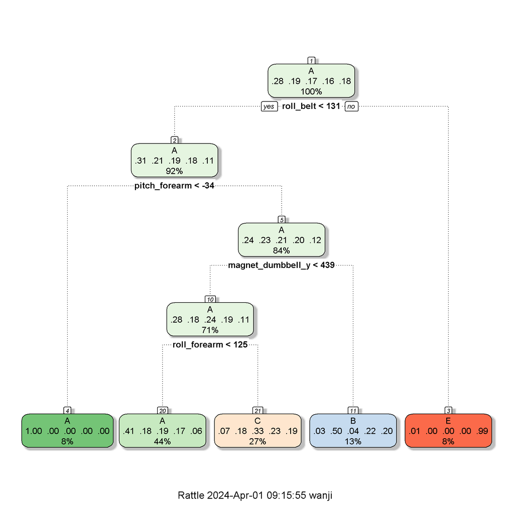

```r
library(rattle)
fancyRpartPlot(mod_tree$finalModel)
```

```r
pred <- predict(mod_tree, newdata=train_data)
confusionMatrix(pred,factor(train_data$classe))
```

```
## Confusion Matrix and Statistics
##
##           Reference
## Prediction    A    B    C    D    E
##          A 3820 1185 1202 1073  383
##          B   66  962   77  426  381
##          C  291  701 1288  913  735
##          D    0    0    0    0    0
##          E    8    0    0    0 1207
##
## Overall Statistics
##
##                Accuracy : 0.4944
##                  95% CI : (0.4863, 0.5025)
##     No Information Rate : 0.2843
##     P-Value [Acc > NIR] : < 2.2e-16
##
##                   Kappa : 0.3392
##
##  Mcnemar's Test P-Value : NA
##
## Statistics by Class:
##
##                      Class: A Class: B Class: C Class: D Class: E
## Sensitivity            0.9128  0.33778  0.50175   0.0000  0.44605
## Specificity            0.6351  0.91997  0.78273   1.0000  0.99933
## Pos Pred Value         0.4985  0.50314  0.32790      NaN  0.99342
## Neg Pred Value         0.9483  0.85273  0.88146   0.8361  0.88899
## Prevalence             0.2843  0.19350  0.17441   0.1639  0.18386
## Detection Rate         0.2595  0.06536  0.08751   0.0000  0.08201
## Detection Prevalence   0.5207  0.12991  0.26688   0.0000  0.08255
## Balanced Accuracy      0.7740  0.62887  0.64224   0.5000  0.72269
```

```r
pred <- predict(mod_tree, newdata=test_data)
confusionMatrix(pred,factor(test_data$classe))
```

```
## Confusion Matrix and Statistics
##
##           Reference
## Prediction    A    B    C    D    E
##          A 1260  401  390  381  140
##          B   21  331   32  146  109
##          C  108  217  433  277  228
##          D    0    0    0    0    0
##          E    6    0    0    0  424
##
## Overall Statistics
##
##                Accuracy : 0.4992
##                  95% CI : (0.4851, 0.5133)
##     No Information Rate : 0.2845
##     P-Value [Acc > NIR] : < 2.2e-16
##
##                   Kappa : 0.345
##
##  Mcnemar's Test P-Value : NA
##
## Statistics by Class:
##
##                      Class: A Class: B Class: C Class: D Class: E
## Sensitivity            0.9032   0.3488   0.5064   0.0000  0.47059
## Specificity            0.6261   0.9221   0.7950   1.0000  0.99850
## Pos Pred Value         0.4899   0.5180   0.3428      NaN  0.98605
## Neg Pred Value         0.9421   0.8551   0.8841   0.8361  0.89338
## Prevalence             0.2845   0.1935   0.1743   0.1639  0.18373
## Detection Rate         0.2569   0.0675   0.0883   0.0000  0.08646
## Detection Prevalence   0.5245   0.1303   0.2575   0.0000  0.08768
## Balanced Accuracy      0.7647   0.6355   0.6507   0.5000  0.73454
```

The out of sample accuracy is 49%, which is not very high.

#### 5.3 Random Forest

```r
library(randomForest)
mod_rf <- train(as.factor(classe)~., method="rf",data=train_data, prox=TRUE,
                ntrees = 10)
print(mod_rf)
```

```
## Random Forest
##
## 14718 samples
##    52 predictor
##     5 classes: 'A', 'B', 'C', 'D', 'E'
##
## No pre-processing
## Resampling: Bootstrapped (25 reps)
## Summary of sample sizes: 14718, 14718, 14718, 14718, 14718, 14718, ...
## Resampling results across tuning parameters:
##
##   mtry  Accuracy   Kappa
##    2    0.9884323  0.9853550
##   27    0.9890020  0.9860766
##   52    0.9801410  0.9748602
##
## Accuracy was used to select the optimal model using the largest value.
## The final value used for the model was mtry = 27.
```

```r
pred <- predict(mod_rf, newdata=train_data)
confusionMatrix(pred,factor(train_data$classe))
```

```
## Confusion Matrix and Statistics
##
##           Reference
## Prediction    A    B    C    D    E
##          A 4185    0    0    0    0
##          B    0 2848    0    0    0
##          C    0    0 2567    0    0
##          D    0    0    0 2412    0
##          E    0    0    0    0 2706
##
## Overall Statistics
##
##                Accuracy : 1
##                  95% CI : (0.9997, 1)
##     No Information Rate : 0.2843
##     P-Value [Acc > NIR] : < 2.2e-16
##
##                   Kappa : 1
##
##  Mcnemar's Test P-Value : NA
##
## Statistics by Class:
##
##                      Class: A Class: B Class: C Class: D Class: E
## Sensitivity            1.0000   1.0000   1.0000   1.0000   1.0000
## Specificity            1.0000   1.0000   1.0000   1.0000   1.0000
## Pos Pred Value         1.0000   1.0000   1.0000   1.0000   1.0000
## Neg Pred Value         1.0000   1.0000   1.0000   1.0000   1.0000
## Prevalence             0.2843   0.1935   0.1744   0.1639   0.1839
## Detection Rate         0.2843   0.1935   0.1744   0.1639   0.1839
## Detection Prevalence   0.2843   0.1935   0.1744   0.1639   0.1839
## Balanced Accuracy      1.0000   1.0000   1.0000   1.0000   1.0000
```

The accuracy is 100%. This model is pretty good.

```r
pred <- predict(mod_rf, newdata=test_data)
confusionMatrix(pred,factor(test_data$classe))
```

```
## Confusion Matrix and Statistics
##
##           Reference
## Prediction    A    B    C    D    E
##          A 1394    6    0    0    2
##          B    1  943    7    0    0
##          C    0    0  845   14    1
##          D    0    0    3  788    1
##          E    0    0    0    2  897
##
## Overall Statistics
##
##                Accuracy : 0.9925
##                  95% CI : (0.9896, 0.9947)
##     No Information Rate : 0.2845
##     P-Value [Acc > NIR] : < 2.2e-16
##
##                   Kappa : 0.9905
##
##  Mcnemar's Test P-Value : NA
##
## Statistics by Class:
##
##                      Class: A Class: B Class: C Class: D Class: E
## Sensitivity            0.9993   0.9937   0.9883   0.9801   0.9956
## Specificity            0.9977   0.9980   0.9963   0.9990   0.9995
## Pos Pred Value         0.9943   0.9916   0.9826   0.9949   0.9978
## Neg Pred Value         0.9997   0.9985   0.9975   0.9961   0.9990
## Prevalence             0.2845   0.1935   0.1743   0.1639   0.1837
## Detection Rate         0.2843   0.1923   0.1723   0.1607   0.1829
## Detection Prevalence   0.2859   0.1939   0.1754   0.1615   0.1833
## Balanced Accuracy      0.9985   0.9958   0.9923   0.9896   0.9975
```

At last, let’s predict the class of the testing data set.

```r
classe_test <- predict(mod_rf, testing)
print(testing$problem_id)
```

```
##  [1]  1  2  3  4  5  6  7  8  9 10 11 12 13 14 15 16 17 18 19 20
```

```r
print(classe_test)
```

```
##  [1] B A B A A E D B A A B C B A E E A B B B
## Levels: A B C D E
```

### 6. Summary

Compared random forest and classification trees, on this typical data set, random forest performs much better than trees. However, random forest takes way more times than classification trees on training these data. A further development on these data can be : 1. Removing some of the features. From the plots, we can see that some of the variables are not helpful on classify these data, which can be removed to increase the efficiency of the training. 2. It is possible to use multiple models to increase the accuracy.